# Final Project

Yajiao Liu

2025-06-06

1.Introduction

The Central African Republic (CAR) is a sparsely populated, landlocked country at the heart of the African continent.Despite being endowed with abundant natural resources (470 mining sites, with oil, gold, and diamonds as the primary resources), it remains one of the poorest and most fragile countries in the world.It exports natural resources (gold, diamonds, timber but must import almost everything else, especially manufactured goods and fuel.In 2023,the total estimate GDP $3.03billion, and its imports accounts for 14.44% and the imports 29.04%(https://www.theglobaleconomy.com/).

In this report ,we will incorporate various statistical methods to analysis the Central African Republic Exports time series data from 1960 to 2017.This data set contains 58 observations and 9 variables. However,we are only interested the Import and GDP variables. Analyzing these two variables, we can see the relationship between GDP and Imports,and how the data can make a predict for the future economy of The Central African Republic.

2.Exploratory Data Analysis

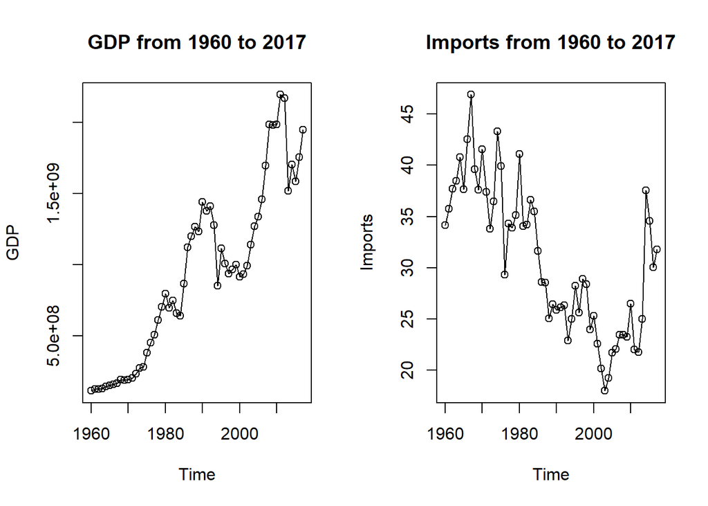

From the picture of GDP,we we can see that there is a trend as the time changes, form 1960 to 2017. The GDP is increasing even though there is some drops, the whole trend is increasing so the data of GDP is non-stationary.

From the Imports plot, there appears to be decreasing over years before 2000, after 2000 ,there is a trend of increasing. This may also imply that this time series is non-stationary.

To verify this ,we plot the ACF and PACF(provided in the Appendix).The ACF of GDP and Imports show an exponential decay which confirms that both time series are not stationary.

The PACF for both series have a large spike at lag 1 and then several non-zero values afterward. This decay imply that they have unit roots, which indicate that the value of today is highly dependent on the the past.

Since it is not stationary, we need to do the transformation or do first order differencing to stable the variance and get the stationary results.

3.Model Selection

3.1 Transformation

3.1.1 Log

We do some transformation on the data. The first one we choose is a log transformation(provided in the Appendix). After applying the log transformation ,we can see that this is little improvement. The ACF still was exponentially decaying.Further,we will do more transformations.In order to find the best lambda to transform, we use the boxcox to choose the most suitable value ,the best value for both Imports and DGP is about 0.5. However,the result does not work very well.The data also have the same trend as the original data.The ACF and PACF also show the similar results as before.In this situation, we need to do further study to make the time series stationary.

3.1.2 Box-cox transformation

3.2 Differencing

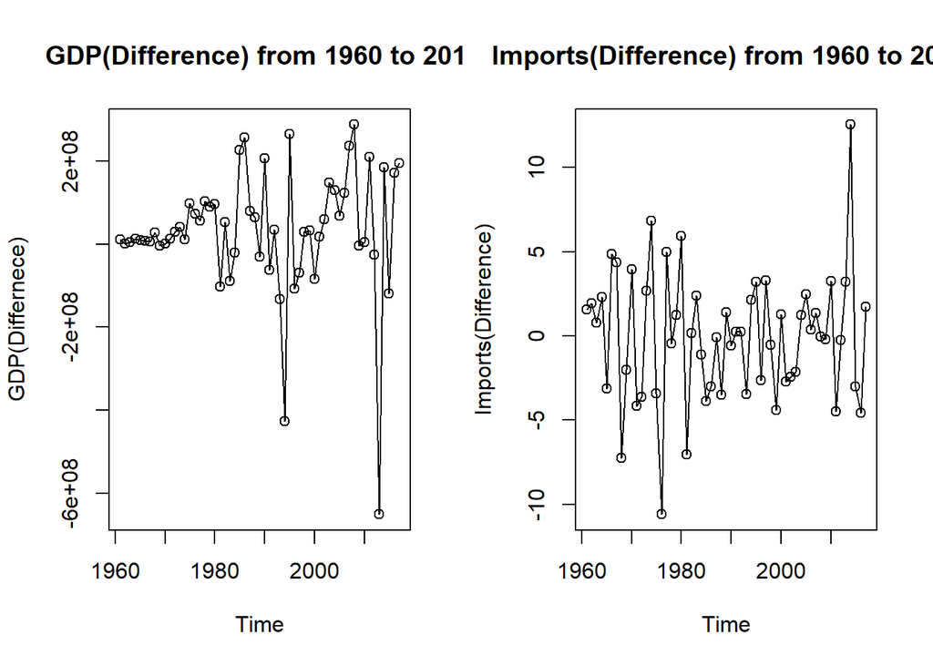

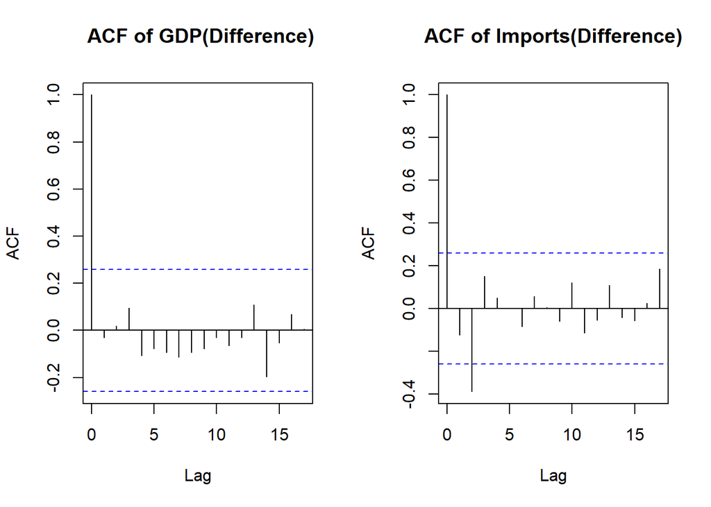

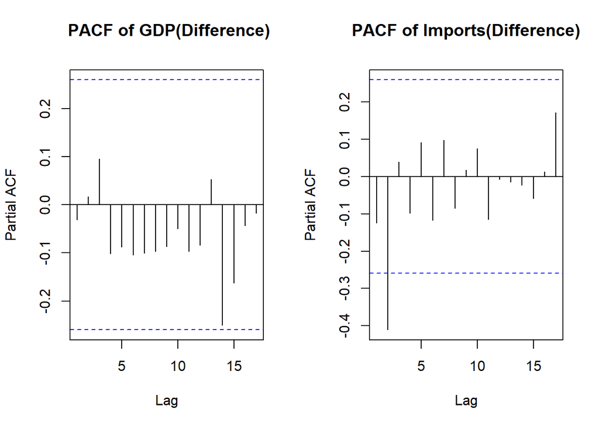

Because we do the box-cox to get the value about 0.5, it means that the value just change the half and the trend does not change.Using the log we can see that the y value changes, so we want to ignore the lambda= 0.5,just consider the log transformation and see what happens when we do the difference to the log Transformation.Here is the result:

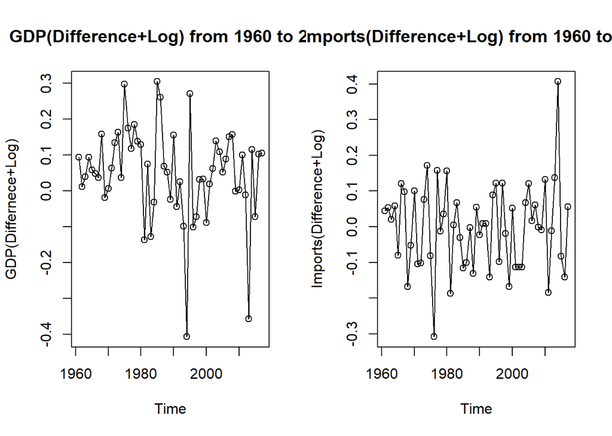

From the picture,we can see that the log is better for the GDP than the original data , the variance is more stable.In this circumstances, we will use the log function and first order difference for the GDP data.As for the Imports data ,the results look similar, then we will see the ACF to see if there is the difference .

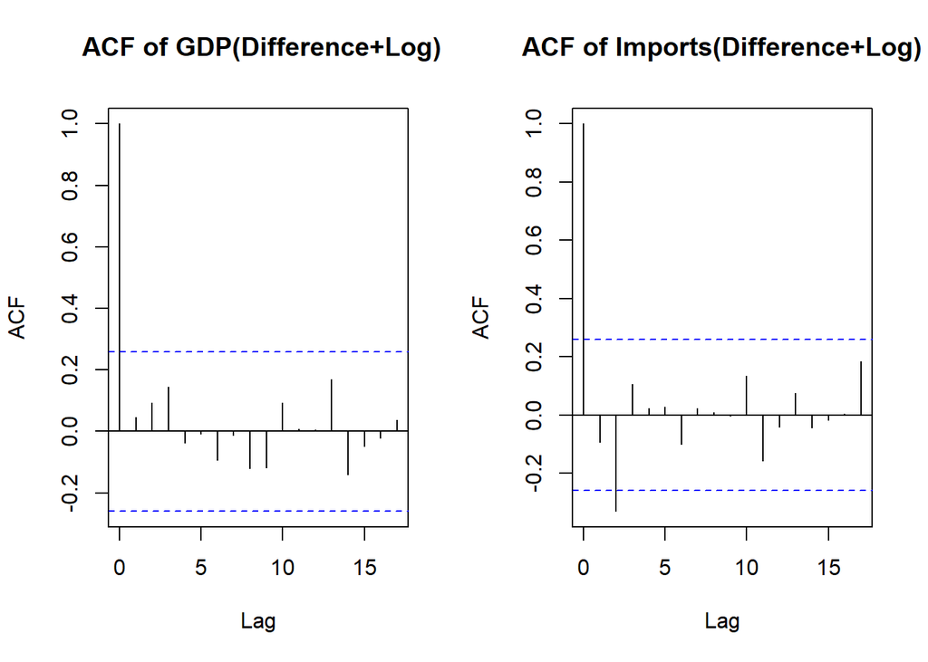

From the ACF and PACF, we can not see the difference with log or not, so we will use the original data for the Imports time series.

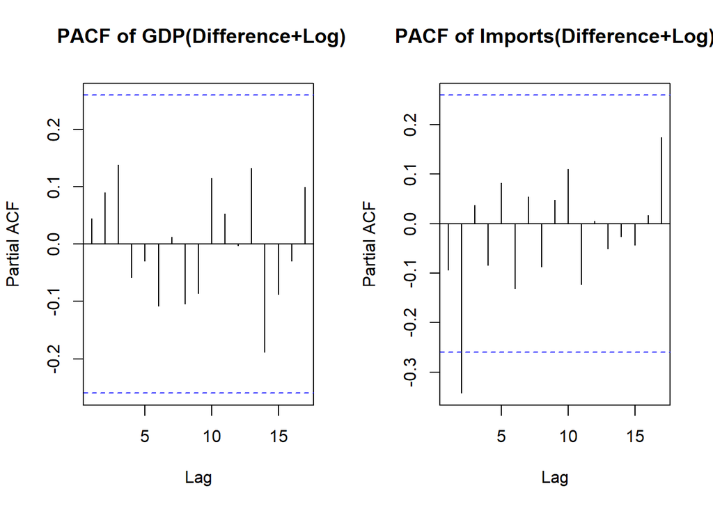

After doing the first order differencing, we get improved ACF and PACF plots that follow what we expected.

3.4 Model-GDP

3.5 Model-Imports

As for another time series Import ,we will do the same thing.As we said before, the ACF and the PACF of the original data does similar like the log function after the first order differencing, so we chose the original data for simplicity instead of choosing the log function the data.From the ACF we can assume the ARIMA(0,1,2)might be appropriate because it is zero after the third lag.While from the PACF it looks like an ARIMA(2,1,0) model would be appropriate because the lags are zero after lag 2.Therefore we decided to fit both of these models.

We first fitted the ARIMA(0,1,2) model to estimate the coefficients(provided in the appedix). As a result, we got the following model:

$$Z_t=-0.1157-0.0528 w_{t-1}-0.4622
w_{t-2} + w_t$$

For this model however, only -0.4622 is significant because the p-values 0.0019 is smaller than 0.1, so we reject the null hypothesis that the coefficient is equal to 0. The remaining terms have a p-value of 0.6 which is greater than 0.1 so they are not significant, we fail to reject the null hypothesis that the coefficient is equal to 0. After dropping the insignificant coefficients we get the following model:

$$Z_t = -0.4622\, w_{t-2} +
w_t$$

Next, we fitted the ARIMA(2,1,0) model and got the following model as a result:

$$Z_t =
-0.0531-0.1733Z_{t-1}-0.4105Z_{t-2} + w_t$$

In this case, only-0.4105 is significant because its p-values 0.0012 is smaller than 0.1, so we reject the null hypothesis that the coefficient is equal to 0. The rest has a p-value (0.1554 and 0.8558 respectively) greater than 0.1 so it is not significant, we fail to reject the null hypothesis that the coefficient is equal to 0. Therefore, we can drop the mean and now get that the actual ARIMA(2,1,0) model is:
$$Z_t = -0.4105Z_{t-2} +
w_t$$

```
## <><><><><><><><><><><><><><>
##
## Coefficients:
##          Estimate     SE t.value p.value
## ar1       -0.1733 0.1203 -1.4410  0.1554
## ar2       -0.4105 0.1196 -3.4317  0.0012
## constant  -0.0531 0.2906 -0.1826  0.8558
##
## sigma^2 estimated as 11.81063 on 54 degrees of freedom
##
## AIC = 5.453971  AICc = 5.461916  BIC = 5.597343
##
```

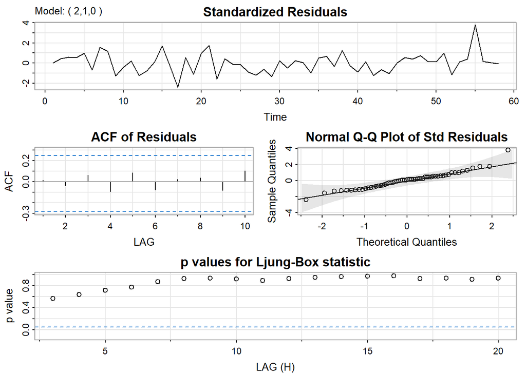

```
## $fit
##
## Call:
## arima(x = xdata, order = c(p, d, q), seasonal = list(order = c(P, D, Q), period = S),
##     xreg = constant, transform.pars = trans, fixed = fixed, optim.control = list(trace = trc,
##         REPORT = 1, reltol = tol))
##
## Coefficients:
##           ar1      ar2  constant
##       -0.1733  -0.4105   -0.0531
## s.e.   0.1203   0.1196    0.2906
##
## sigma^2 estimated as 11.81:  log likelihood = -151.44,  aic = 310.88
##
## $degrees_of_freedom
## [1] 54
##
## $ttable
##          Estimate     SE t.value p.value
## ar1       -0.1733 0.1203 -1.4410  0.1554
## ar2       -0.4105 0.1196 -3.4317  0.0012
## constant  -0.0531 0.2906 -0.1826  0.8558
##
## $ICs
##      AIC     AICc      BIC
## 5.453971 5.461916 5.597343
```

3.6 Final Model

Once we selected the ARIMA(2,1,0) model, we conducted residual diagnostics and got the results shown above. From the Normal Q-Q plot we see that the residuals are normal as they follow a linear trend. In addition, from the ACF of the Residuals we see that all the lags are between the dashed lines which indicates that the residuals follow white noise. This is confirmed by the Ljung-Box test in which we see that all p-values are above the dashed line. This means that all p-values are greater than 0.1, which means that we fail to reject the null hypothesis that residuals follow white noise. Thus, we conclude that the residuals do follow white noise. These findings confirm that our model is appropriate and ready to be used for forecasting.

4.Forecast

Since we selected ARIMA(2,1,0) as the more reasonable model, we used it to forecast the imports for the next 10 years. We obtained the point forecasts and the corresponding confidence intervals for the next 10 years up until 2027.

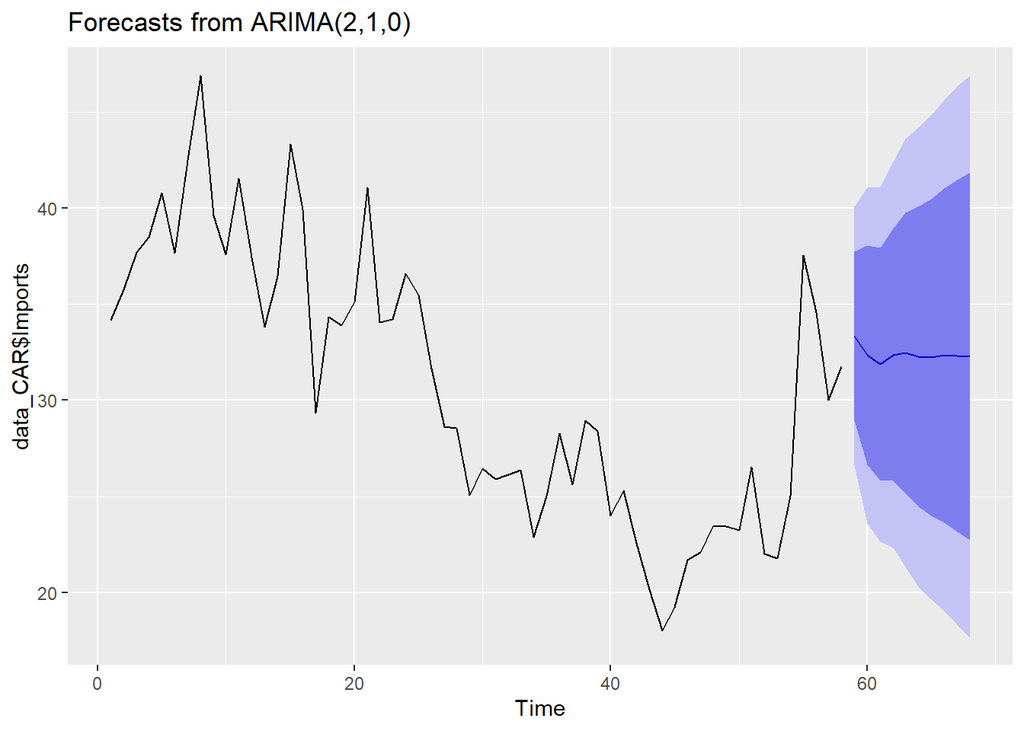

5.Conclusion

```r
knitr::opts_chunk$set(echo = FALSE, warning = FALSE, message = FALSE)
load("C:/Users/Gilli/OneDrive/Desktop/STA137/finalproject.Rdata")
sapply(finalPro_data,class)
```

```
##    Country       Code       Year        GDP     Growth        CPI    Imports
##   "factor"   "factor"  "numeric"  "numeric"  "numeric"  "numeric"  "numeric"
##    Exports Population
##  "numeric"  "numeric"
```

```r
data_CAR <- finalPro_data[, c("Year", "GDP", "Imports")]
sum(is.na(data_CAR))
```

```
## [1] 0
```

```r
summary(data_CAR)
```

```
##       Year           GDP               Imports
##  Min.   :1960   Min.   :1.122e+08   Min.   :18.00
##  1st Qu.:1974   1st Qu.:3.057e+08   1st Qu.:25.03
##  Median :1988   Median :9.348e+08   Median :29.68
##  Mean   :1988   Mean   :9.394e+08   Mean   :30.83
##  3rd Qu.:2003   3rd Qu.:1.367e+09   3rd Qu.:36.58
##  Max.   :2017   Max.   :2.196e+09   Max.   :46.90
```

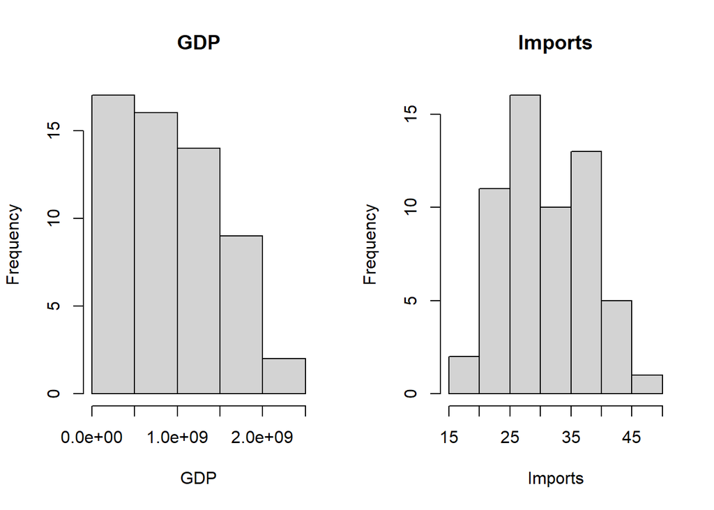

```r
par(mfrow = c(1, 2))
hist(data_CAR$GDP,main = "GDP",xlab = 'GDP')
hist(data_CAR$Imports,main="Imports",xlab = 'Imports')
```

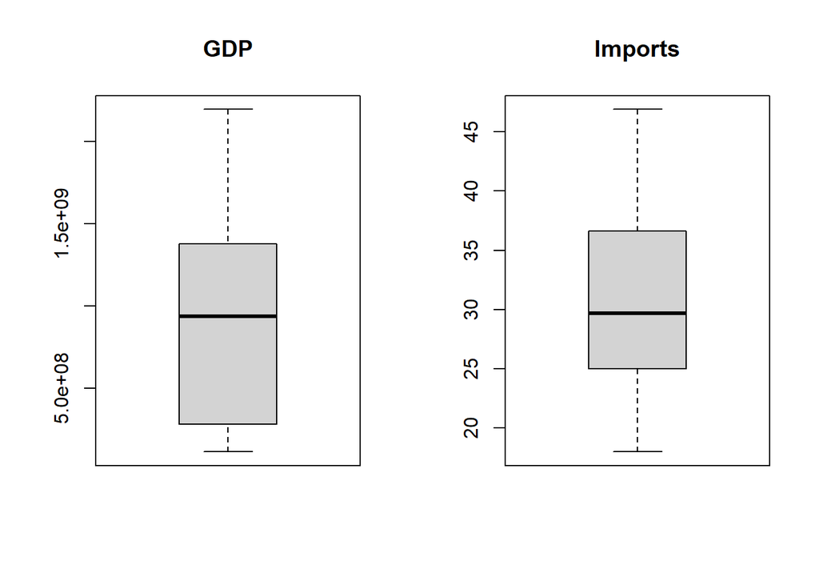

```r
par(mfrow = c(1, 2))
boxplot(data_CAR$GDP, main="GDP")
boxplot(data_CAR$Imports,main="Imports")
```

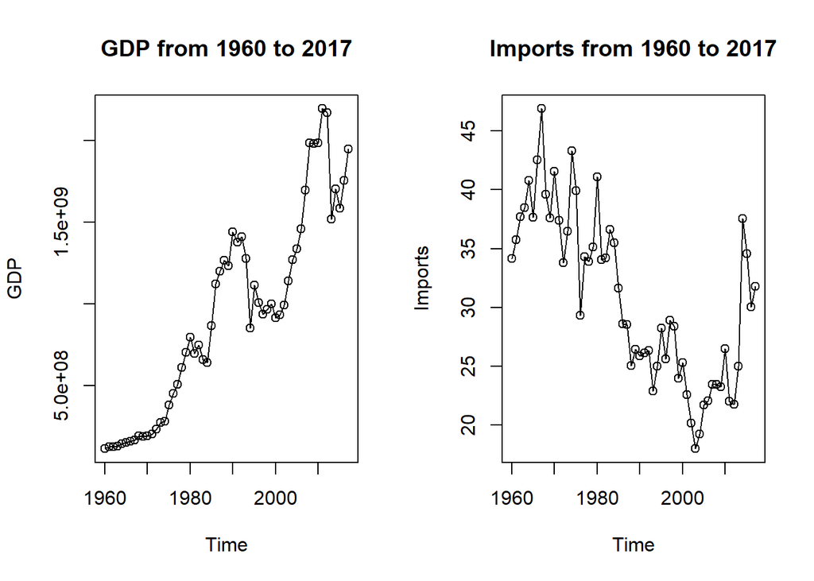

```r
par(mfrow = c(1, 2))
plot(data_CAR$Year, data_CAR$GDP, type="o",main="GDP from 1960 to 2017",xlab = 'Time', ylab="GDP")
plot(data_CAR$Year,data_CAR$Imports,type="o",main="Imports from 1960 to 2017",xlab = 'Time', ylab="Imports")
```

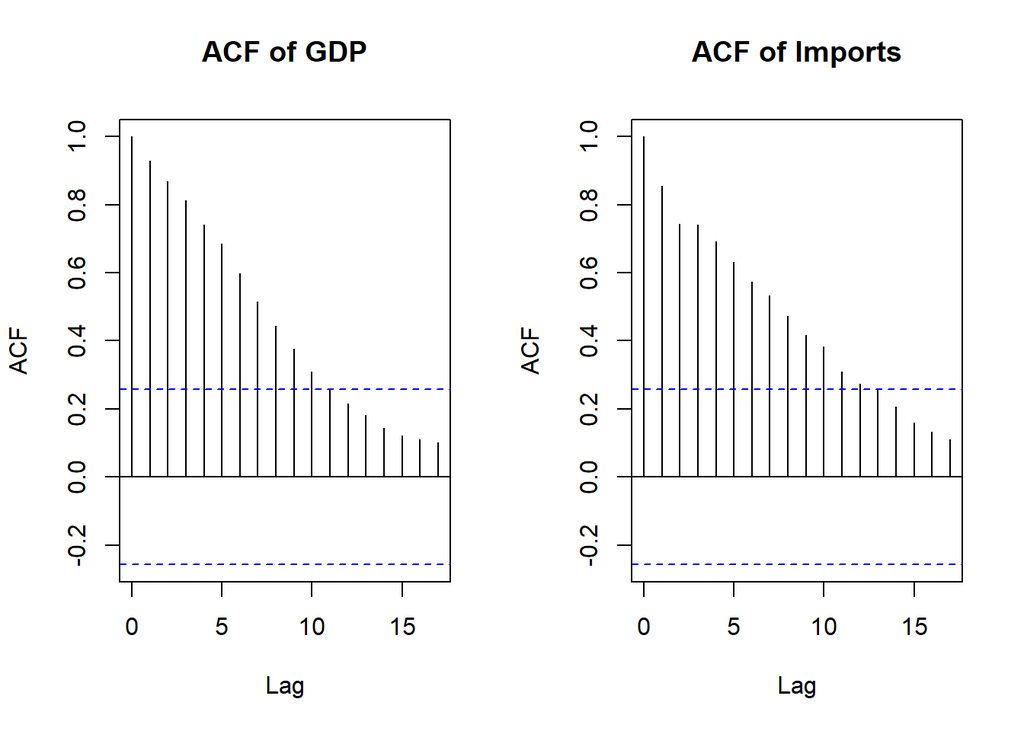

```r
par(mfrow = c(1, 2))
acf(data_CAR$GDP, main = "ACF of GDP")
acf(data_CAR$Imports, main = "ACF of Imports")
```

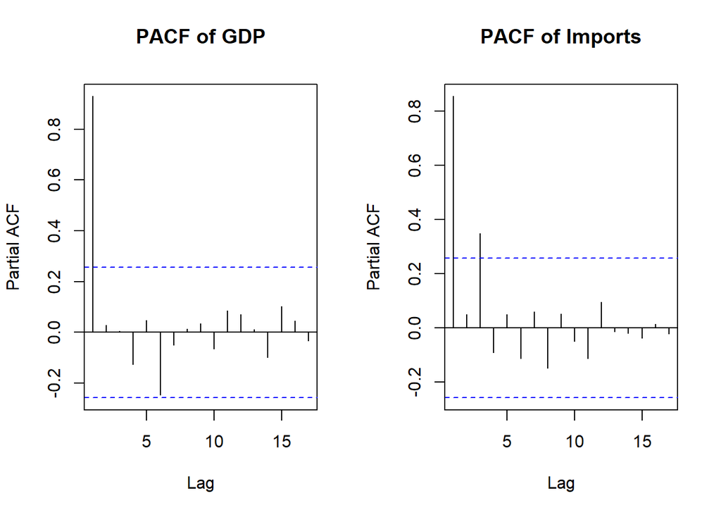

```r
par(mfrow = c(1, 2))
pacf(data_CAR$GDP, main = "PACF of GDP")
pacf(data_CAR$Imports, main = "PACF of Imports")
```

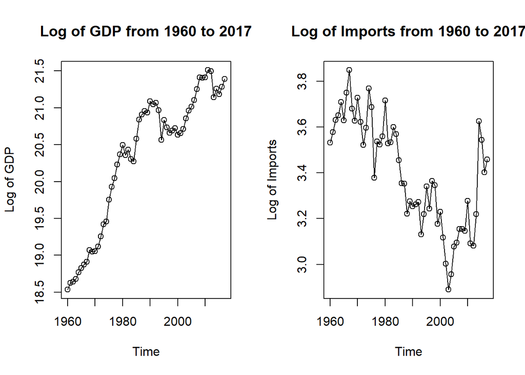

```r
par(mfrow = c(1, 2))
plot(data_CAR$Year, log(data_CAR$GDP), type="o",main="Log of GDP from 1960 to 2017",xlab = 'Time', ylab="Log of GDP")
plot(data_CAR$Year,log(data_CAR$Imports),type="o",main="Log of Imports from 1960 to 2017",xlab = 'Time', ylab="Log of Imports")
```

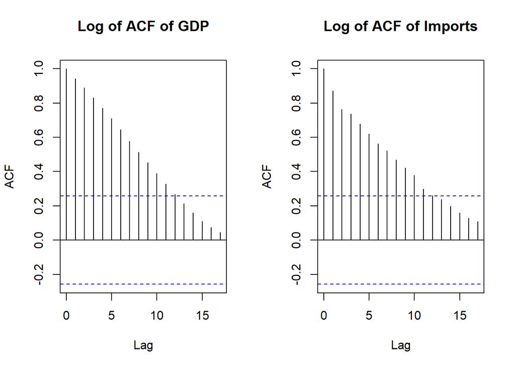

```r
par(mfrow = c(1, 2))
acf(log(data_CAR$GDP), main = "Log of ACF of GDP")
acf(log(data_CAR$Imports), main = "Log of ACF of Imports")
```

```r
library(MASS)
par(mfrow = c(1, 2))
bc <- boxcox(GDP ~ Year, data = data_CAR)
lambda_GDP <- bc$x[which.max(bc$y)]
lambda_GDP
```

```
## [1] 0.5050505
```

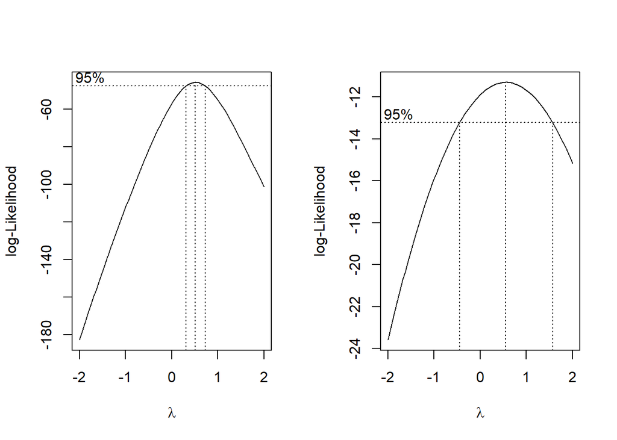

```r
ac <- boxcox(Imports ~ Year, data = data_CAR)
```

```r
lambda_Im <- ac$x[which.max(ac$y)]
lambda_Im
```

```
## [1] 0.5454545
```

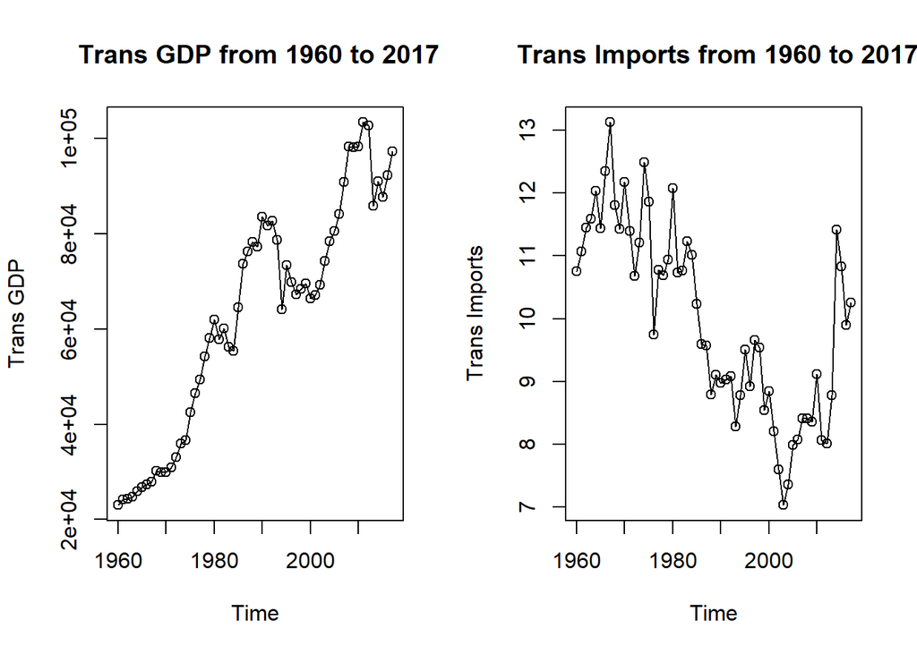

```r
GDP_trans <- (data_CAR$GDP^lambda_GDP - 1) / lambda_GDP
Im_trans <- (data_CAR$Imports^lambda_Im - 1) / lambda_Im
plot(data_CAR$Year,GDP_trans, type="o",main=" Trans GDP from 1960 to 2017",xlab = 'Time', ylab="Trans GDP")
plot(data_CAR$Year,Im_trans, type="o",main=" Trans Imports from 1960 to 2017",xlab = 'Time', ylab="Trans Imports")
```

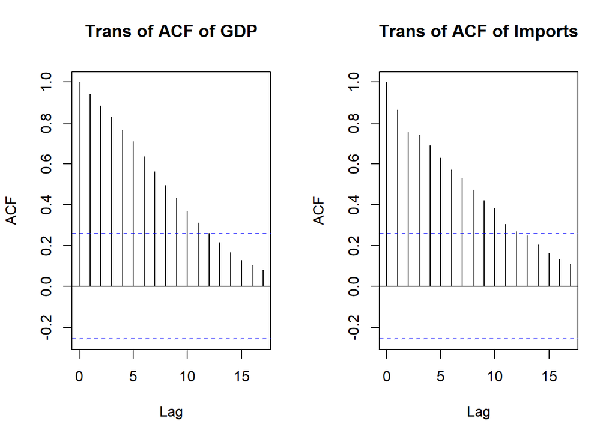

```r
par(mfrow = c(1, 2))
acf(GDP_trans, main = "Trans of ACF of GDP")
acf(Im_trans, main = "Trans of ACF of Imports")
```

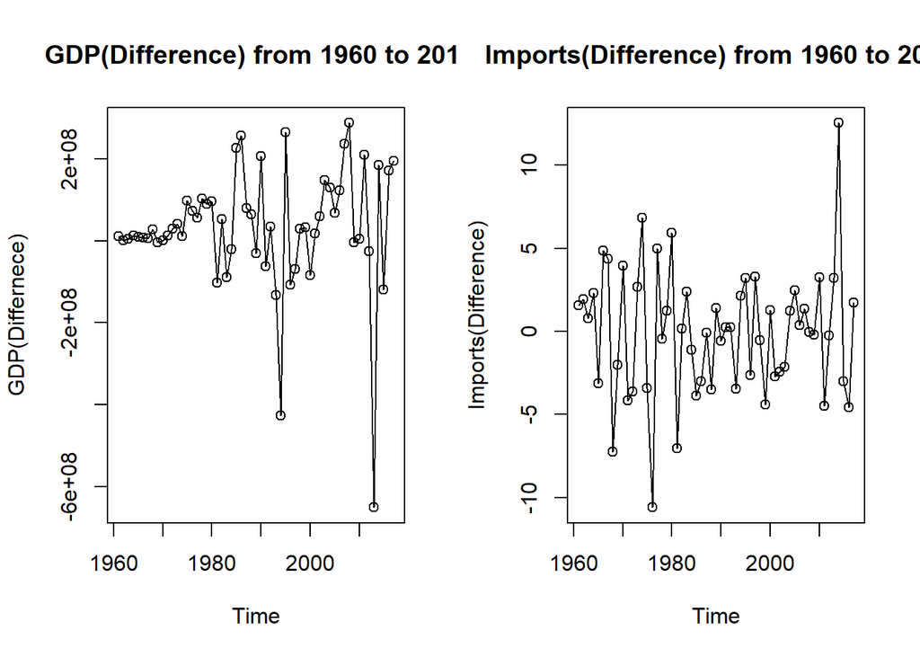

```r
par(mfrow = c(1, 2))
differ_GDP=diff(data_CAR$GDP)
differ_Imports= diff(data_CAR$Imports)
diff_Year <- data_CAR$Year[-1]
plot(diff_Year,differ_GDP, type="o",main=" GDP(Difference) from 1960 to 2017",xlab = 'Time', ylab="GDP(Differnece)")
plot(diff_Year,differ_Imports, type="o",main=" Imports(Difference) from 1960 to 2017",xlab = 'Time', ylab="Imports(Difference)")
```

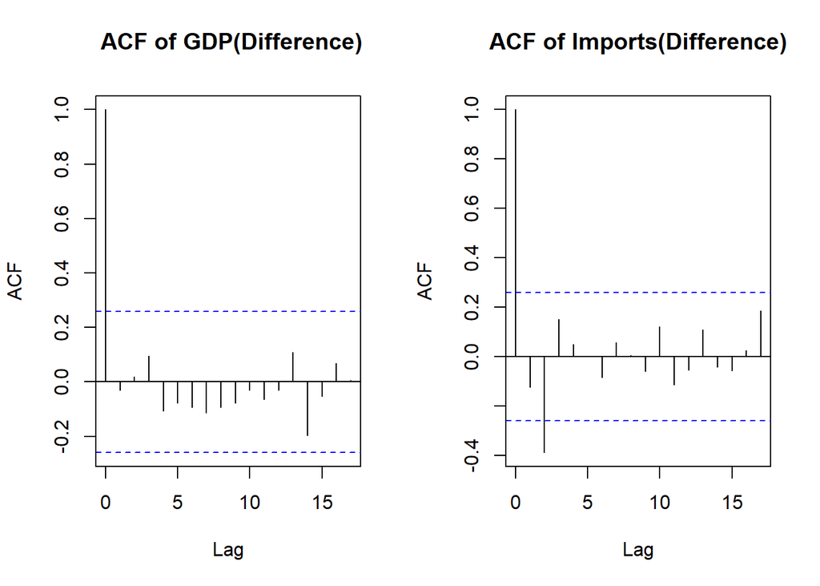

```r
par(mfrow = c(1, 2))
acf(differ_GDP, main = " ACF of GDP(Difference)")
acf(differ_Imports, main = "ACF of Imports(Difference)")
```

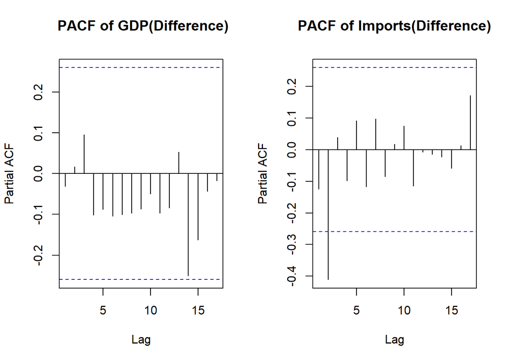

```r
par(mfrow = c(1, 2))
pacf(differ_GDP, main = " PACF of GDP(Difference)")
pacf(differ_Imports, main = "PACF of Imports(Difference)")
```

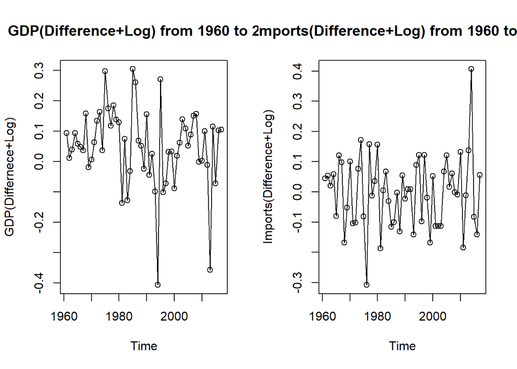

```r
par(mfrow = c(1, 2))
differ_log_GDP=diff(log(data_CAR$GDP))
differ_log_Imports=diff(log(data_CAR$Imports))
diff_Year <- data_CAR$Year[-1]
plot(diff_Year,differ_log_GDP, type="o",main=" GDP(Difference+Log) from 1960 to 2017",xlab = 'Time', ylab="GDP(Differnece+Log)")
plot(diff_Year,differ_log_Imports, type="o",main=" Imports(Difference+Log) from 1960 to 2017",xlab = 'Time', ylab="Imports(Difference+Log)")
```

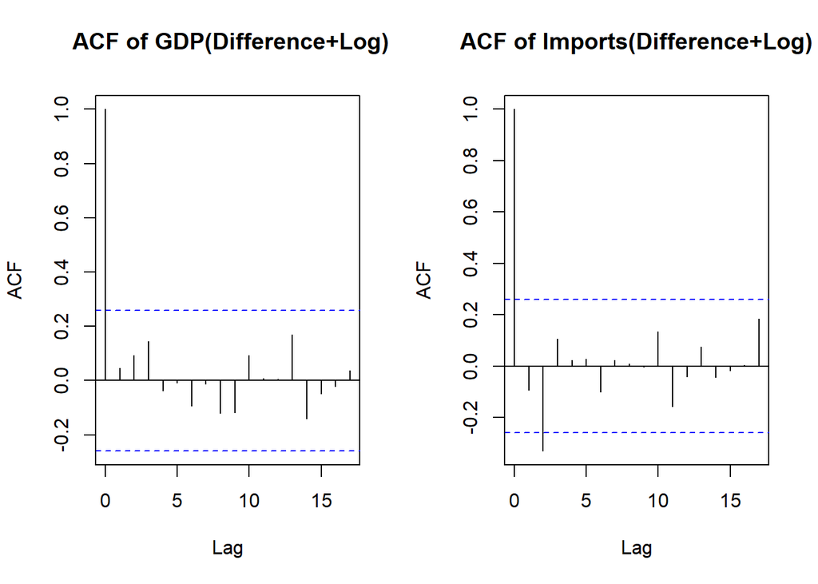

```r
par(mfrow = c(1, 2))
acf(differ_log_GDP, main = " ACF of GDP(Difference+Log)")
acf(differ_log_Imports, main = "ACF of Imports(Difference+Log)")
```

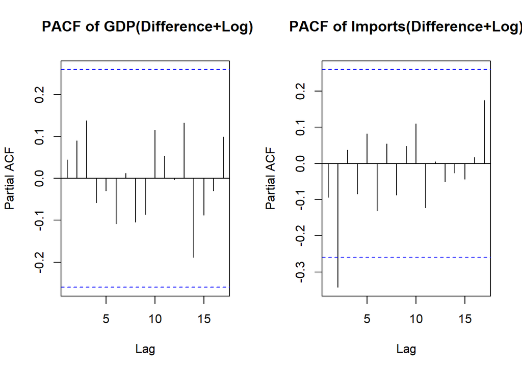

```r
par(mfrow = c(1, 2))
pacf(differ_log_GDP, main = " PACF of GDP(Difference+Log)")
pacf(differ_log_Imports, main = "PACF of Imports(Difference+Log)")
```

```r
library(astsa)
model_AR <- arima(log(data_CAR$GDP), order = c(1,1,0))
model_AR
```

```
##
## Call:
## arima(x = log(data_CAR$GDP), order = c(1, 1, 0))
##
## Coefficients:
##          ar1
##       0.1642
## s.e.  0.1306
##
## sigma^2 estimated as 0.01851:  log likelihood = 32.8,  aic = -61.61
```

```
## <><><><><><><><><><><><><><>
##
## Coefficients:
##          Estimate     SE t.value p.value
## ar1        0.0444 0.1315  0.3380  0.7367
## constant   0.0502 0.0178  2.8207  0.0067
##
## sigma^2 estimated as 0.01649082 on 55 degrees of freedom
##
## AIC = -1.161776  AICc = -1.157878  BIC = -1.054247
##
```

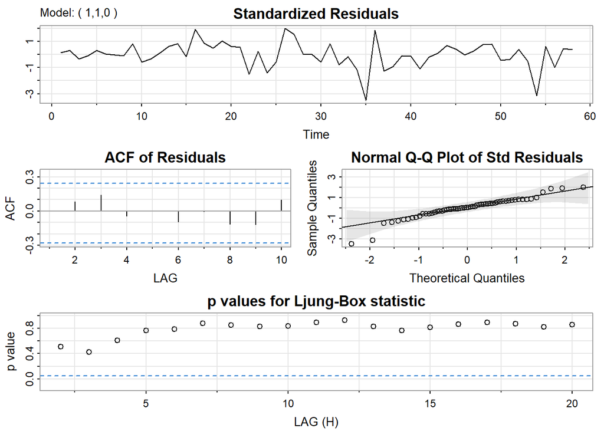

```r
model_AR_PARA=sarima(log(data_CAR$GDP),1,1,0)
```

```r
model_AR_PARA
```

```
## $fit
##
## Call:
## arima(x = xdata, order = c(p, d, q), seasonal = list(order = c(P, D, Q), period = S),
##     xreg = constant, transform.pars = trans, fixed = fixed, optim.control = list(trace = trc,
##         REPORT = 1, reltol = tol))
##
## Coefficients:
##          ar1  constant
##       0.0444    0.0502
## s.e.  0.1315    0.0178
##
## sigma^2 estimated as 0.01649:  log likelihood = 36.11,  aic = -66.22
##
## $degrees_of_freedom
## [1] 55
##
## $ttable
##          Estimate     SE t.value p.value
## ar1        0.0444 0.1315  0.3380  0.7367
## constant   0.0502 0.0178  2.8207  0.0067
##
## $ICs
##       AIC      AICc       BIC
## -1.161776 -1.157878 -1.054247
```

```r
model_MA <- arima(log(data_CAR$GDP), order = c(0,1,1))
model_MA
```

```
##
## Call:
## arima(x = log(data_CAR$GDP), order = c(0, 1, 1))
##
## Coefficients:
##          ma1
##       0.1267
## s.e.  0.1182
##
## sigma^2 estimated as 0.01864:  log likelihood = 32.61,  aic = -61.22
```

```
## <><><><><><><><><><><><><><>
##
## Coefficients:
##          Estimate     SE t.value p.value
## ma1        0.0382 0.1228  0.3113  0.7568
## constant   0.0502 0.0177  2.8416  0.0063
##
## sigma^2 estimated as 0.01649574 on 55 degrees of freedom
##
## AIC = -1.161487  AICc = -1.157589  BIC = -1.053958
##
```

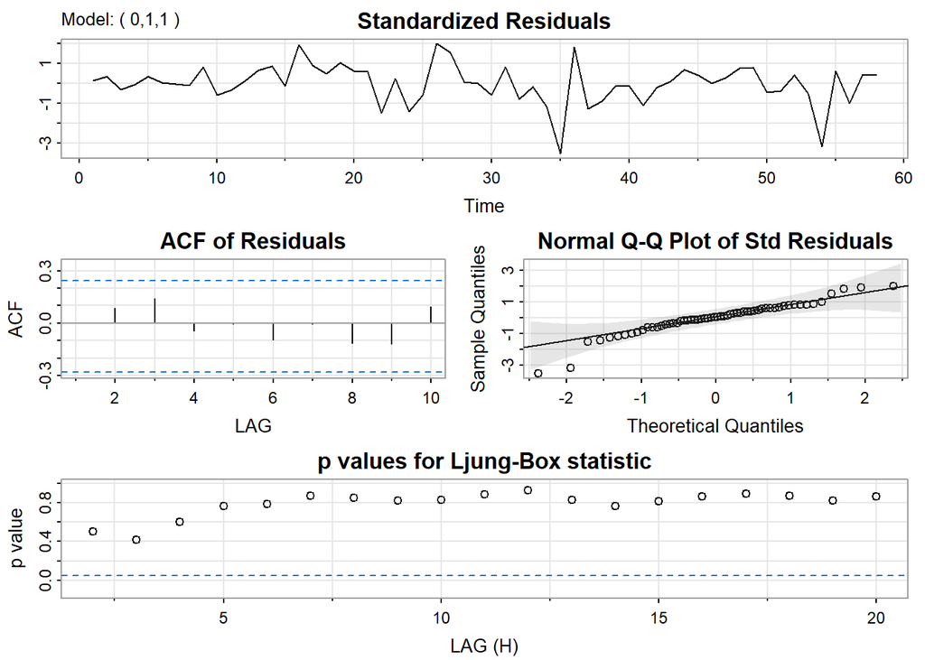

```r
model_MA_PARA=sarima(log(data_CAR$GDP),0,1,1)
```

```r
model_MA_PARA
```

```
## $fit
##
## Call:
## arima(x = xdata, order = c(p, d, q), seasonal = list(order = c(P, D, Q), period = S),
##     xreg = constant, transform.pars = trans, fixed = fixed, optim.control = list(trace = trc,
##         REPORT = 1, reltol = tol))
##
## Coefficients:
##          ma1  constant
##       0.0382    0.0502
## s.e.  0.1228    0.0177
##
## sigma^2 estimated as 0.0165:  log likelihood = 36.1,  aic = -66.2
##
## $degrees_of_freedom
## [1] 55
##
## $ttable
##          Estimate     SE t.value p.value
## ma1        0.0382 0.1228  0.3113  0.7568
## constant   0.0502 0.0177  2.8416  0.0063
##
## $ICs
##       AIC      AICc       BIC
## -1.161487 -1.157589 -1.053958
```

```r
model_MA_AR <- arima(data_CAR$GDP, order = c(2,1,2))
model_MA_AR
```

```
##
## Call:
## arima(x = data_CAR$GDP, order = c(2, 1, 2))
##
## Coefficients:
##          ar1      ar2      ma1     ma2
##       1.5045  -0.8903  -1.5105  0.9999
## s.e.  0.1218   0.1037   0.0749  0.0722
##
## sigma^2 estimated as 2.063e+16:  log likelihood = -1153.07,  aic = 2316.14
```

```
## <><><><><><><><><><><><><><>
##
## Coefficients:
##          Estimate     SE  t.value p.value
## ar1        1.5232 0.1236  12.3224  0.0000
## ar2       -0.9044 0.0924  -9.7839  0.0000
## ma1       -1.5297 0.1006 -15.2086  0.0000
## ma2        1.0000 0.0999  10.0098  0.0000
## constant   0.0508 0.0196   2.5979  0.0122
##
## sigma^2 estimated as 0.01443687 on 52 degrees of freedom
##
## AIC = -1.138155  AICc = -1.117515  BIC = -0.9230966
##
```

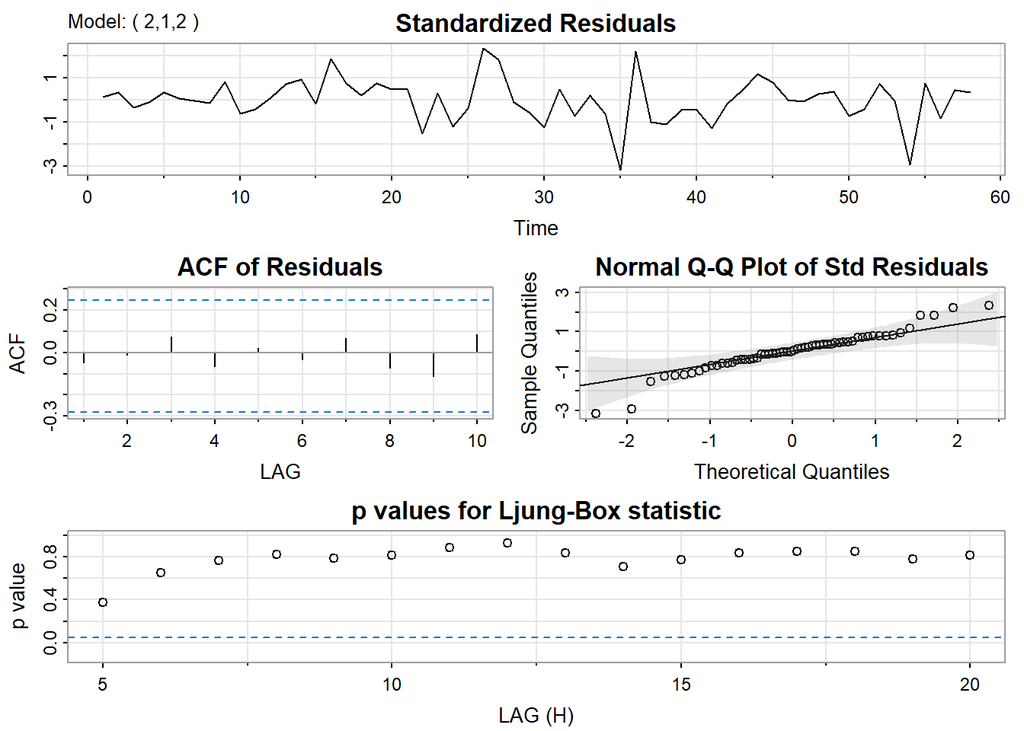

```r
model_MA_AR_PARA=sarima(log(data_CAR$GDP),2,1,2)
```

```r
model_MA_AR_PARA
```

```
## $fit
##
## Call:
## arima(x = xdata, order = c(p, d, q), seasonal = list(order = c(P, D, Q), period = S),
##     xreg = constant, transform.pars = trans, fixed = fixed, optim.control = list(trace = trc,
##         REPORT = 1, reltol = tol))
##
## Coefficients:
##          ar1      ar2      ma1     ma2  constant
##       1.5232  -0.9044  -1.5297  1.0000    0.0508
## s.e.  0.1236   0.0924   0.1006  0.0999    0.0196
##
## sigma^2 estimated as 0.01444:  log likelihood = 38.44,  aic = -64.87
##
## $degrees_of_freedom
## [1] 52
##
## $ttable
##          Estimate     SE  t.value p.value
## ar1        1.5232 0.1236  12.3224  0.0000
## ar2       -0.9044 0.0924  -9.7839  0.0000
## ma1       -1.5297 0.1006 -15.2086  0.0000
## ma2        1.0000 0.0999  10.0098  0.0000
## constant   0.0508 0.0196   2.5979  0.0122
##
## $ICs
##        AIC       AICc        BIC
## -1.1381546 -1.1175148 -0.9230966
```

```r
Box.test(residuals(model_MA_AR), lag = 10, type = "Ljung-Box")
```

```
##
##  Box-Ljung test
##
## data:  residuals(model_MA_AR)
## X-squared = 2.8076, df = 10, p-value = 0.9856
```

```r
model_MA_AR_none <- arima(log(data_CAR$GDP), order = c(0,1,0))
model_MA_AR_none
```

```
##
## Call:
## arima(x = log(data_CAR$GDP), order = c(0, 1, 0))
##
##
## sigma^2 estimated as 0.01903:  log likelihood = 32.02,  aic = -62.05
```

```
## <><><><><><><><><><><><><><>
##
## Coefficients:
##          Estimate    SE t.value p.value
## constant   0.0501 0.017  2.9421  0.0047
##
## sigma^2 estimated as 0.01652443 on 56 degrees of freedom
##
## AIC = -1.194863  AICc = -1.193587  BIC = -1.123177
##
```

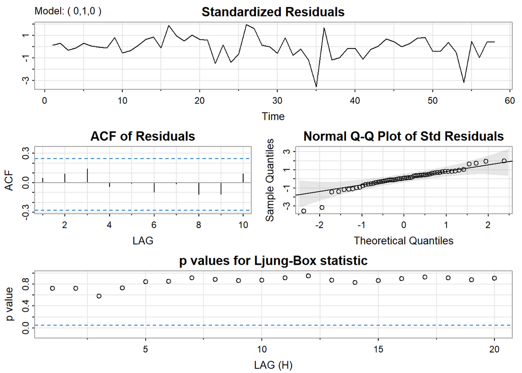

```r
model_MA_AR_none_PARA_=sarima(log(data_CAR$GDP),0,1,0)
```

```r
model_MA_AR_PARA
```

```
## $fit
##
## Call:
## arima(x = xdata, order = c(p, d, q), seasonal = list(order = c(P, D, Q), period = S),
##     xreg = constant, transform.pars = trans, fixed = fixed, optim.control = list(trace = trc,
##         REPORT = 1, reltol = tol))
##
## Coefficients:
##          ar1      ar2      ma1     ma2  constant
##       1.5232  -0.9044  -1.5297  1.0000    0.0508
## s.e.  0.1236   0.0924   0.1006  0.0999    0.0196
##
## sigma^2 estimated as 0.01444:  log likelihood = 38.44,  aic = -64.87
##
## $degrees_of_freedom
## [1] 52
##
## $ttable
##          Estimate     SE  t.value p.value
## ar1        1.5232 0.1236  12.3224  0.0000
## ar2       -0.9044 0.0924  -9.7839  0.0000
## ma1       -1.5297 0.1006 -15.2086  0.0000
## ma2        1.0000 0.0999  10.0098  0.0000
## constant   0.0508 0.0196   2.5979  0.0122
##
## $ICs
##        AIC       AICc        BIC
## -1.1381546 -1.1175148 -0.9230966
```

```r
model_MA_Import <- arima(data_CAR$Imports, order = c(0,1,2))
model_MA_Import
```

```
##
## Call:
## arima(x = data_CAR$Imports, order = c(0, 1, 2))
##
## Coefficients:
##           ma1      ma2
##       -0.0463  -0.4473
## s.e.   0.1307   0.1361
##
## sigma^2 estimated as 11.9:  log likelihood = -151.68,  aic = 309.37
```

```
## <><><><><><><><><><><><><><>
##
## Coefficients:
##          Estimate     SE t.value p.value
## ma1       -0.0528 0.1300 -0.4065  0.6860
## ma2       -0.4622 0.1416 -3.2636  0.0019
## constant  -0.1157 0.2333 -0.4960  0.6219
##
## sigma^2 estimated as 11.84284 on 54 degrees of freedom
##
## AIC = 5.458552  AICc = 5.466496  BIC = 5.601924
##
```

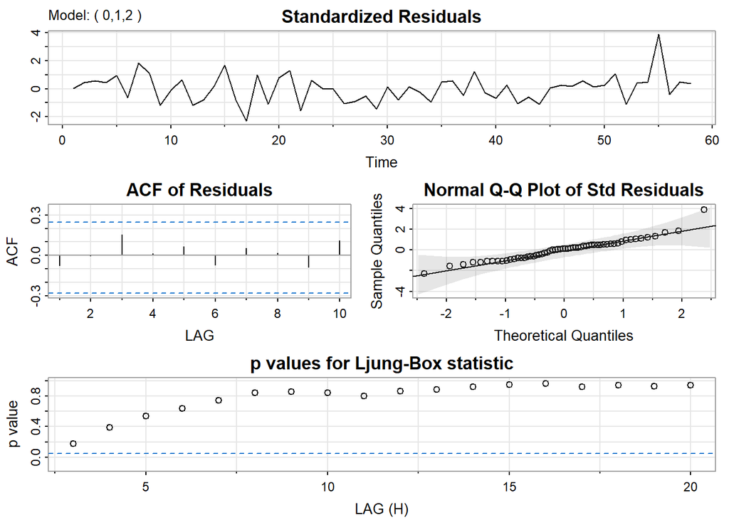

```r
model_MA_Import_PARA=sarima(data_CAR$Imports,0,1,2)
```

```r
model_MA_Import_PARA
```

```
## $fit
##
## Call:
## arima(x = xdata, order = c(p, d, q), seasonal = list(order = c(P, D, Q), period = S),
##     xreg = constant, transform.pars = trans, fixed = fixed, optim.control = list(trace = trc,
##         REPORT = 1, reltol = tol))
##
## Coefficients:
##           ma1      ma2  constant
##       -0.0528  -0.4622   -0.1157
## s.e.   0.1300   0.1416    0.2333
##
## sigma^2 estimated as 11.84:  log likelihood = -151.57,  aic = 311.14
##
## $degrees_of_freedom
## [1] 54
##
## $ttable
##          Estimate     SE t.value p.value
## ma1       -0.0528 0.1300 -0.4065  0.6860
## ma2       -0.4622 0.1416 -3.2636  0.0019
## constant  -0.1157 0.2333 -0.4960  0.6219
##
## $ICs
##      AIC     AICc      BIC
## 5.458552 5.466496 5.601924
```

```
## <><><><><><><><><><><><><><>
##
## Coefficients:
##          Estimate     SE t.value p.value
## ar1       -0.1733 0.1203 -1.4410  0.1554
## ar2       -0.4105 0.1196 -3.4317  0.0012
## constant  -0.0531 0.2906 -0.1826  0.8558
##
## sigma^2 estimated as 11.81063 on 54 degrees of freedom
##
## AIC = 5.453971  AICc = 5.461916  BIC = 5.597343
##
```

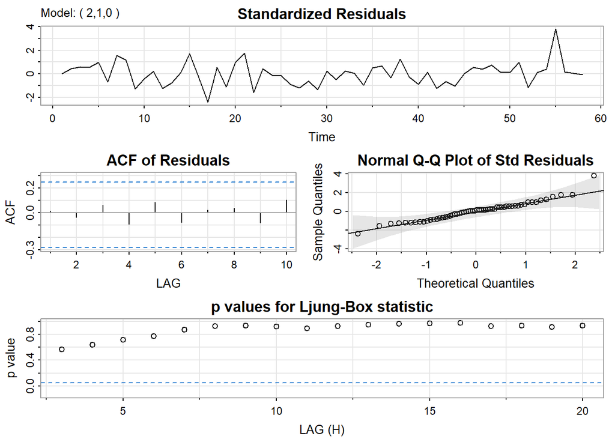

```r
model_AR_Import <- arima(data_CAR$Imports, order = c(2,1,0))
model_AR_Import_PARA=sarima(data_CAR$Imports,2,1,0)
```